[figure not shown]

# Python libraries for working with data

```python
# Copyright (c) Thalesians Ltd, 2019-2023. All rights reserved.
# Copyright (c) Paul Alexander Bilokon, 2019-2023. All rights reserved.
# Author: Paul Alexander Bilokon <paul@thalesians.com>
# This version: 2.0 (2023.11.17)
# Previous versions: 1.0 (2019.03.25)
# Email: info@thalesians.com
```

## Motivation

Two third-party (but *de facto* standard) Python libraries play a particular role in Data Analysis: `pandas` and NumPy.

The data types defined in `pandas` — `DataFrame` and `Series` — enable the data scientist to work effectively with tables. `pandas` provides some of the functionality that we find in SQL databases and spreadsheets. Since much of the data that we deal with comes in the form of tables, `pandas` is extremely useful.

NumPy provides a lower-level type — the multidimensional array. This data type is used as an underlying implementation by `pandas` `DataFrame`s and `Series`. NumPy arrays are used wherever bulk operations on numbers are needed in Python, which is what much of Data Science is about. NumPy arrays can be seen as a Python implementation of the key linear algebra object — the matrix.

## Objectives

1. To introduce `pandas` `DataFrames` and `Series`.
2. To show how... ...to quickly inspect a `pandas` `DataFrame`.
3. ...`pandas` `DataFrame`s can be indexed using `loc` and `iloc`.
4. ...`DataFrame`'s columns can be indexed.
5. ...to iterate through columns of a `DataFrame`.
6. ...a `DataFrame` can be effectively summarised.
7. ...to add a column to a `DataFrame`.
8. ...to overwrite a column in a `DataFrame`.
9. ...to rearrange columns in a `DataFrame`.
10. ...to delete a column from a `DataFrame`.
11. ...to apply a function to a column in a `DataFrame`.
12. ...to filter data in a `DataFrame` based on some boolean expression.
13. ...to deal with missing data (NaNs).
14. ...to use `groupby`.
15. ...to append to a `DataFrame`.
16. ...to join on a `DataFrame`.
17. ...to get at the NumPy arrays behind the `pandas` `DataFrame` and `Series`.
18. ...to define one-dimensional (flat) NumPy arrays.
19. ...to use `np.arange`, `np.linspace`, and `np.logspace`.
20. To explain the reasons to prefer NumPy arrays over standard Python data structures, such as lists.
21. To show how... ...to define two-dimensional NumPy arrays, thus implementing matrices.
22. ...to create NumPy arrays using `np.zeros`, `np.ones`, `np.full`, `np.empty`, `np.tile`.
23. ...to use 32-bit floating point numbers (`float32`) instead of 64-bit floating point numbers in NumPy arrays.
24. ...to generate random matrices.
25. ...to reshape matrices.
26. ...to multiply matrices by scalars.
27. ...to add matrices together.
28. ...to multiply matrices together.
29. ...to mix arrays and scalars in arithmetic operations; to explain broadcasting.
30. ...to transpose matrices.
31. ...to invert matrices.
32. ...to create identity matrices.
33. ...to stack NumPy arrays horizontally.
34. ...to stack NumPy arrays vertically.
35. ...to index NumPy arrays, including boolean indices.
36. ...to compare NumPy arrays.
37. ...to use some useful functions: `np.cumsum`, `np.cumprod`, `np.min`, `np.max`, `np.argmin`, `np.argmax`, `np.mean`, `np.var`, `np.std`.
38. ...to apply a function to each row/column in a NumPy array.
39. ...to use NumPy array flags.
40. ...to make NumPy arrays immutable (kind of).
41. ...to find out more about the configuration of the NumPy library, e.g. which BLAS it is using.

## `pandas` `DataFrame`s and `Series`

`pandas` is an open source, BSD-licensed library providing high-performance, easy-to-use data structures and data analysis tools for the Python programming language. We can import it with

```python
import pandas as pd
```

The key data type provided by `pandas` is `DataFrame`. Let us create one:

```python
df = pd.DataFrame(
    {
        'transaction date': [2012.917, 2012.917, 2013.583, 2013.500, 2012.833, 2012.667, 2012.667, 2013.417, 2013.500, 2013.417, 2013.083, 2013.333, 2012.917, 2012.667, 2013.500],
        'distance to the nearest MRT station': [84.87882, 306.59470, 561.98450, 561.98450, 390.56840, 2175.03000, 623.47310, 287.60250, 5512.03800, 1783.18000, 405.21340, 90.45606, 492.23130, 2469.64500, 1164.83800],
        'number of convenience stores': [10, 9, 5, 5, 5, 3, 7, 6, 1, 3, 1, 9, 5, 4, 4],
        'latitude': [24.98298, 24.98034, 24.98746, 24.98746, 24.97937, 24.96305, 24.97933, 24.98042, 24.95095, 24.96731, 24.97349, 24.97433, 24.96515, 24.96108, 24.99156],
        'longitude': [121.54024, 121.53951, 121.54391, 121.54391, 121.54245, 121.51254, 121.53642, 121.54228, 121.48458, 121.51486, 121.53372, 121.54310, 121.53737, 121.51046, 121.53406],
        'house price per unit area': [37.9, 42.2, 47.3, 54.8, 43.1, 32.1, 40.3, 46.7, 18.8, 22.1, 41.4, 58.1, 39.3, 23.8, 34.3]
    },
    columns=[
        'transaction date',
        'distance to the nearest MRT station',
        'number of convenience stores',
        'latitude',
        'longitude',
        'house price per unit area'
    ])
```

`pandas` `DataFrame`s in many ways resemble SQL database tables and worksheets in spreadsheet applications.

### How to quickly inspect a `DataFrame`

Let's examine our newly created `DataFrame`:

```python
df
```

|  | transaction date | distance to the nearest MRT station | number of convenience stores | latitude | longitude | house price per unit area |
| --- | --- | --- | --- | --- | --- | --- |
| 0 | 2012.917 | 84.87882 | 10 | 24.98298 | 121.54024 | 37.9 |
| 1 | 2012.917 | 306.59470 | 9 | 24.98034 | 121.53951 | 42.2 |
| 2 | 2013.583 | 561.98450 | 5 | 24.98746 | 121.54391 | 47.3 |
| 3 | 2013.500 | 561.98450 | 5 | 24.98746 | 121.54391 | 54.8 |
| 4 | 2012.833 | 390.56840 | 5 | 24.97937 | 121.54245 | 43.1 |
| 5 | 2012.667 | 2175.03000 | 3 | 24.96305 | 121.51254 | 32.1 |
| 6 | 2012.667 | 623.47310 | 7 | 24.97933 | 121.53642 | 40.3 |
| 7 | 2013.417 | 287.60250 | 6 | 24.98042 | 121.54228 | 46.7 |
| 8 | 2013.500 | 5512.03800 | 1 | 24.95095 | 121.48458 | 18.8 |
| 9 | 2013.417 | 1783.18000 | 3 | 24.96731 | 121.51486 | 22.1 |
| 10 | 2013.083 | 405.21340 | 1 | 24.97349 | 121.53372 | 41.4 |
| 11 | 2013.333 | 90.45606 | 9 | 24.97433 | 121.54310 | 58.1 |
| 12 | 2012.917 | 492.23130 | 5 | 24.96515 | 121.53737 | 39.3 |
| 13 | 2012.667 | 2469.64500 | 4 | 24.96108 | 121.51046 | 23.8 |
| 14 | 2013.500 | 1164.83800 | 4 | 24.99156 | 121.53406 | 34.3 |

In practice, we may be dealing with `DataFrame`s containing thousands of rows of data (not fifteen, as in our example). So instead of looking at the entire `DataFrame` we may look at its...

```python
df.head()
```

|  | transaction date | distance to the nearest MRT station | number of convenience stores | latitude | longitude | house price per unit area |
| --- | --- | --- | --- | --- | --- | --- |
| 0 | 2012.917 | 84.87882 | 10 | 24.98298 | 121.54024 | 37.9 |
| 1 | 2012.917 | 306.59470 | 9 | 24.98034 | 121.53951 | 42.2 |
| 2 | 2013.583 | 561.98450 | 5 | 24.98746 | 121.54391 | 47.3 |
| 3 | 2013.500 | 561.98450 | 5 | 24.98746 | 121.54391 | 54.8 |
| 4 | 2012.833 | 390.56840 | 5 | 24.97937 | 121.54245 | 43.1 |

We may wish to look at more rows from the `DataFrame`'s head:

```python
df.head(10)
```

|  | transaction date | distance to the nearest MRT station | number of convenience stores | latitude | longitude | house price per unit area |
| --- | --- | --- | --- | --- | --- | --- |
| 0 | 2012.917 | 84.87882 | 10 | 24.98298 | 121.54024 | 37.9 |
| 1 | 2012.917 | 306.59470 | 9 | 24.98034 | 121.53951 | 42.2 |
| 2 | 2013.583 | 561.98450 | 5 | 24.98746 | 121.54391 | 47.3 |
| 3 | 2013.500 | 561.98450 | 5 | 24.98746 | 121.54391 | 54.8 |
| 4 | 2012.833 | 390.56840 | 5 | 24.97937 | 121.54245 | 43.1 |
| 5 | 2012.667 | 2175.03000 | 3 | 24.96305 | 121.51254 | 32.1 |
| 6 | 2012.667 | 623.47310 | 7 | 24.97933 | 121.53642 | 40.3 |
| 7 | 2013.417 | 287.60250 | 6 | 24.98042 | 121.54228 | 46.7 |
| 8 | 2013.500 | 5512.03800 | 1 | 24.95095 | 121.48458 | 18.8 |
| 9 | 2013.417 | 1783.18000 | 3 | 24.96731 | 121.51486 | 22.1 |

Or examine its tail:

```python
df.tail()
```

|  | transaction date | distance to the nearest MRT station | number of convenience stores | latitude | longitude | house price per unit area |
| --- | --- | --- | --- | --- | --- | --- |
| 10 | 2013.083 | 405.21340 | 1 | 24.97349 | 121.53372 | 41.4 |
| 11 | 2013.333 | 90.45606 | 9 | 24.97433 | 121.54310 | 58.1 |
| 12 | 2012.917 | 492.23130 | 5 | 24.96515 | 121.53737 | 39.3 |
| 13 | 2012.667 | 2469.64500 | 4 | 24.96108 | 121.51046 | 23.8 |
| 14 | 2013.500 | 1164.83800 | 4 | 24.99156 | 121.53406 | 34.3 |

### The index of the `DataFrame`, `loc` and `iloc`

Notice the numbers in bold on the left. These constitute the **index** of the `DataFrame`:

```python
list(df.index)
```

```
[0, 1, 2, 3, 4, 5, 6, 7, 8, 9, 10, 11, 12, 13, 14]
```

We can access the list of **columns** of the data frame through

```python
list(df.columns)
```

```
['transaction date',
 'distance to the nearest MRT station',
 'number of convenience stores',
 'latitude',
 'longitude',
 'house price per unit area']
```

Thus the index indexes the rows, whereas the column names index the columns. We can access individual rows of the `DataFrame` through

```python
df.loc[3]
```

```
transaction date                       2013.50000
distance to the nearest MRT station     561.98450
number of convenience stores              5.00000
latitude                                 24.98746
longitude                               121.54391
house price per unit area                54.80000
Name: 3, dtype: float64
```

Notice that the index of the data frame doesn't have to be formed from integers starting with zero, as in our case

```python
list(df.index)
```

```
[0, 1, 2, 3, 4, 5, 6, 7, 8, 9, 10, 11, 12, 13, 14]
```

We could have chosen to index the rows with strings, `'A', 'B', 'C', 'D', 'E', 'F', 'G', 'H', 'I', 'J', 'K', 'L', 'M', 'N', 'O'`. Since the `DataFrame` is a **mutable** object, i.e. it can be changed after construction, we can replace its index accordingly:

```python
df.index = ['A', 'B', 'C', 'D', 'E', 'F', 'G', 'H', 'I', 'J', 'K', 'L', 'M', 'N', 'O']
```

```python
df.head()
```

|  | transaction date | distance to the nearest MRT station | number of convenience stores | latitude | longitude | house price per unit area |
| --- | --- | --- | --- | --- | --- | --- |
| A | 2012.917 | 84.87882 | 10 | 24.98298 | 121.54024 | 37.9 |
| B | 2012.917 | 306.59470 | 9 | 24.98034 | 121.53951 | 42.2 |
| C | 2013.583 | 561.98450 | 5 | 24.98746 | 121.54391 | 47.3 |
| D | 2013.500 | 561.98450 | 5 | 24.98746 | 121.54391 | 54.8 |
| E | 2012.833 | 390.56840 | 5 | 24.97937 | 121.54245 | 43.1 |

Now we can index the rows with

```python
df.loc['D']
```

```
transaction date                       2013.50000
distance to the nearest MRT station     561.98450
number of convenience stores              5.00000
latitude                                 24.98746
longitude                               121.54391
house price per unit area                54.80000
Name: D, dtype: float64
```

Whatever the index of the `DataFrame`, we can also refer to the rows through their integer offsets from the top, using `iloc` instead of `loc`:

```python
df.iloc[3]
```

```
transaction date                       2013.50000
distance to the nearest MRT station     561.98450
number of convenience stores              5.00000
latitude                                 24.98746
longitude                               121.54391
house price per unit area                54.80000
Name: D, dtype: float64
```

Whereas the type of the entire object is

```python
type(df)
```

```
pandas.core.frame.DataFrame
```

The type of `df.loc['D']` (equivalently, of `df.iloc[3]`) is

```python
type(df.loc['D'])
```

```
pandas.core.series.Series
```

`Series` is the second most important type defined in the `pandas` package (after `DataFrame`).

### Indexing columns

As we said above, the list of columns in the dataframe is accessible through

```python
list(df.columns)
```

```
['transaction date',
 'distance to the nearest MRT station',
 'number of convenience stores',
 'latitude',
 'longitude',
 'house price per unit area']
```

Individual columns can be indexed using

```python
df['latitude']
```

```
A    24.98298
B    24.98034
C    24.98746
D    24.98746
E    24.97937
F    24.96305
G    24.97933
H    24.98042
I    24.95095
J    24.96731
K    24.97349
L    24.97433
M    24.96515
N    24.96108
O    24.99156
Name: latitude, dtype: float64
```

The type of the object thus obtained is

```python
type(df['latitude'])
```

```
pandas.core.series.Series
```

You can also access multiple columns at once using

```python
df[['latitude', 'longitude']]
```

|  | latitude | longitude |
| --- | --- | --- |
| A | 24.98298 | 121.54024 |
| B | 24.98034 | 121.53951 |
| C | 24.98746 | 121.54391 |
| D | 24.98746 | 121.54391 |
| E | 24.97937 | 121.54245 |
| F | 24.96305 | 121.51254 |
| G | 24.97933 | 121.53642 |
| H | 24.98042 | 121.54228 |
| I | 24.95095 | 121.48458 |
| J | 24.96731 | 121.51486 |
| K | 24.97349 | 121.53372 |
| L | 24.97433 | 121.54310 |
| M | 24.96515 | 121.53737 |
| N | 24.96108 | 121.51046 |
| O | 24.99156 | 121.53406 |

The type of the resulting object is `DataFrame`, rather than `Series`:

```python
type(df[['latitude', 'longitude']])
```

```
pandas.core.frame.DataFrame
```

### Iterating through columns

Let us demonstrate how we can iterate through the columns of a `DataFrame`. In this example we shall store the first (0th) value from each column in a dictionary:

```python
firsts = {}
for c in df.columns:
    firsts[c] = df[c].iloc[0]
```

```python
firsts
```

```
{'transaction date': 2012.917,
 'distance to the nearest MRT station': 84.87882,
 'number of convenience stores': 10,
 'latitude': 24.98298,
 'longitude': 121.54024,
 'house price per unit area': 37.9}
```

### Summarising the `DataFrame`

Another quick way to obtain a high-level view of a (potentially very large) `DataFrame` is with

```python
df.info()
```

```
<class 'pandas.core.frame.DataFrame'>
Index: 15 entries, A to O
Data columns (total 6 columns):
 #   Column                               Non-Null Count  Dtype
---  ------                               --------------  -----
 0   transaction date                     15 non-null     float64
 1   distance to the nearest MRT station  15 non-null     float64
 2   number of convenience stores         15 non-null     int64
 3   latitude                             15 non-null     float64
 4   longitude                            15 non-null     float64
 5   house price per unit area            15 non-null     float64
dtypes: float64(5), int64(1)
memory usage: 1.4+ KB
```

whereas the following will present summary statistics for each column:

```python
df.describe()
```

|  | transaction date | distance to the nearest MRT station | number of convenience stores | latitude | longitude | house price per unit area |
| --- | --- | --- | --- | --- | --- | --- |
| count | 15.000000 | 15.000000 | 15.000000 | 15.000000 | 15.000000 | 15.000000 |
| mean | 2013.127867 | 1127.314552 | 5.133333 | 24.974952 | 121.530627 | 38.813333 |
| std | 0.347586 | 1425.732372 | 2.722044 | 0.011395 | 0.017235 | 11.251341 |
| min | 2012.667000 | 84.878820 | 1.000000 | 24.950950 | 121.484580 | 18.800000 |
| 25% | 2012.875000 | 348.581550 | 3.500000 | 24.966230 | 121.524290 | 33.200000 |
| 50% | 2013.083000 | 561.984500 | 5.000000 | 24.979330 | 121.537370 | 40.300000 |
| 75% | 2013.458500 | 1474.009000 | 6.500000 | 24.981700 | 121.542365 | 44.900000 |
| max | 2013.583000 | 5512.038000 | 10.000000 | 24.991560 | 121.543910 | 58.100000 |

### Adding a column

To add a column, assuming the column `'house age'` does not yet exist:

```python
df['house age'] = [32.0, 19.5, 13.3, 13.3, 5.0, 7.1, 34.5, 20.3, 31.7, 17.9, 34.8, 6.3, 13.0, 20.4, 13.2]
```

```python
df.head()
```

|  | transaction date | distance to the nearest MRT station | number of convenience stores | latitude | longitude | house price per unit area | house age |
| --- | --- | --- | --- | --- | --- | --- | --- |
| A | 2012.917 | 84.87882 | 10 | 24.98298 | 121.54024 | 37.9 | 32.0 |
| B | 2012.917 | 306.59470 | 9 | 24.98034 | 121.53951 | 42.2 | 19.5 |
| C | 2013.583 | 561.98450 | 5 | 24.98746 | 121.54391 | 47.3 | 13.3 |
| D | 2013.500 | 561.98450 | 5 | 24.98746 | 121.54391 | 54.8 | 13.3 |
| E | 2012.833 | 390.56840 | 5 | 24.97937 | 121.54245 | 43.1 | 5.0 |

### Overwriting a column

Similarly, if the column `'house age'` already exists,

```python
df['house age'] = [320., 195., 133., 133., 50., 71., 345., 203., 317., 179., 348., 63., 130., 204., 132.]
```

```python
df.head()
```

|  | transaction date | distance to the nearest MRT station | number of convenience stores | latitude | longitude | house price per unit area | house age |
| --- | --- | --- | --- | --- | --- | --- | --- |
| A | 2012.917 | 84.87882 | 10 | 24.98298 | 121.54024 | 37.9 | 320.0 |
| B | 2012.917 | 306.59470 | 9 | 24.98034 | 121.53951 | 42.2 | 195.0 |
| C | 2013.583 | 561.98450 | 5 | 24.98746 | 121.54391 | 47.3 | 133.0 |
| D | 2013.500 | 561.98450 | 5 | 24.98746 | 121.54391 | 54.8 | 133.0 |
| E | 2012.833 | 390.56840 | 5 | 24.97937 | 121.54245 | 43.1 | 50.0 |

### Rearranging the columns

To rearrange the columns:

```python
df = df[[
    'transaction date', 'house age',
    'distance to the nearest MRT station', 'number of convenience stores',
    'latitude', 'longitude',
    'house price per unit area'
]]
```

```python
df.head()
```

|  | transaction date | house age | distance to the nearest MRT station | number of convenience stores | latitude | longitude | house price per unit area |
| --- | --- | --- | --- | --- | --- | --- | --- |
| A | 2012.917 | 320.0 | 84.87882 | 10 | 24.98298 | 121.54024 | 37.9 |
| B | 2012.917 | 195.0 | 306.59470 | 9 | 24.98034 | 121.53951 | 42.2 |
| C | 2013.583 | 133.0 | 561.98450 | 5 | 24.98746 | 121.54391 | 47.3 |
| D | 2013.500 | 133.0 | 561.98450 | 5 | 24.98746 | 121.54391 | 54.8 |
| E | 2012.833 | 50.0 | 390.56840 | 5 | 24.97937 | 121.54245 | 43.1 |

### Deleting a column

```python
del df['house age']
```

```python
df.head()
```

|  | transaction date | distance to the nearest MRT station | number of convenience stores | latitude | longitude | house price per unit area |
| --- | --- | --- | --- | --- | --- | --- |
| A | 2012.917 | 84.87882 | 10 | 24.98298 | 121.54024 | 37.9 |
| B | 2012.917 | 306.59470 | 9 | 24.98034 | 121.53951 | 42.2 |
| C | 2013.583 | 561.98450 | 5 | 24.98746 | 121.54391 | 47.3 |
| D | 2013.500 | 561.98450 | 5 | 24.98746 | 121.54391 | 54.8 |
| E | 2012.833 | 390.56840 | 5 | 24.97937 | 121.54245 | 43.1 |

### Applying a function to a column

```python
import math
```

```python
df['distance to the nearest MRT station'].apply(math.sqrt)
```

```
A     9.212970
B    17.509846
C    23.706212
D    23.706212
E    19.762803
F    46.637217
G    24.969443
H    16.958847
I    74.243101
J    42.227716
K    20.129913
L     9.510839
M    22.186286
N    49.695523
O    34.129723
Name: distance to the nearest MRT station, dtype: float64
```

Notice that the original column hasn't been overwritten:

```python
df.head()
```

|  | transaction date | distance to the nearest MRT station | number of convenience stores | latitude | longitude | house price per unit area |
| --- | --- | --- | --- | --- | --- | --- |
| A | 2012.917 | 84.87882 | 10 | 24.98298 | 121.54024 | 37.9 |
| B | 2012.917 | 306.59470 | 9 | 24.98034 | 121.53951 | 42.2 |
| C | 2013.583 | 561.98450 | 5 | 24.98746 | 121.54391 | 47.3 |
| D | 2013.500 | 561.98450 | 5 | 24.98746 | 121.54391 | 54.8 |
| E | 2012.833 | 390.56840 | 5 | 24.97937 | 121.54245 | 43.1 |

To overwrite it,

```python
df['distance to the nearest MRT station'] = df['distance to the nearest MRT station'].apply(math.sqrt)
```

```python
df.head()
```

|  | transaction date | distance to the nearest MRT station | number of convenience stores | latitude | longitude | house price per unit area |
| --- | --- | --- | --- | --- | --- | --- |
| A | 2012.917 | 9.212970 | 10 | 24.98298 | 121.54024 | 37.9 |
| B | 2012.917 | 17.509846 | 9 | 24.98034 | 121.53951 | 42.2 |
| C | 2013.583 | 23.706212 | 5 | 24.98746 | 121.54391 | 47.3 |
| D | 2013.500 | 23.706212 | 5 | 24.98746 | 121.54391 | 54.8 |
| E | 2012.833 | 19.762803 | 5 | 24.97937 | 121.54245 | 43.1 |

To reverse what we have just done:

```python
df['distance to the nearest MRT station'] = df['distance to the nearest MRT station'].apply(lambda x: x * x)
```

```python
df.head()
```

|  | transaction date | distance to the nearest MRT station | number of convenience stores | latitude | longitude | house price per unit area |
| --- | --- | --- | --- | --- | --- | --- |
| A | 2012.917 | 84.87882 | 10 | 24.98298 | 121.54024 | 37.9 |
| B | 2012.917 | 306.59470 | 9 | 24.98034 | 121.53951 | 42.2 |
| C | 2013.583 | 561.98450 | 5 | 24.98746 | 121.54391 | 47.3 |
| D | 2013.500 | 561.98450 | 5 | 24.98746 | 121.54391 | 54.8 |
| E | 2012.833 | 390.56840 | 5 | 24.97937 | 121.54245 | 43.1 |

### Filtering data

Suppose that we want to consider only those rows where the value in the column `'number of convenience stores'` is greater than or equal to 7. We can then index `df` by

```python
df['number of convenience stores'] >= 7
```

```
A     True
B     True
C    False
D    False
E    False
F    False
G     True
H    False
I    False
J    False
K    False
L     True
M    False
N    False
O    False
Name: number of convenience stores, dtype: bool
```

obtaining, as a result,

```python
df[df['number of convenience stores'] >= 7]
```

|  | transaction date | distance to the nearest MRT station | number of convenience stores | latitude | longitude | house price per unit area |
| --- | --- | --- | --- | --- | --- | --- |
| A | 2012.917 | 84.87882 | 10 | 24.98298 | 121.54024 | 37.9 |
| B | 2012.917 | 306.59470 | 9 | 24.98034 | 121.53951 | 42.2 |
| G | 2012.667 | 623.47310 | 7 | 24.97933 | 121.53642 | 40.3 |
| L | 2013.333 | 90.45606 | 9 | 24.97433 | 121.54310 | 58.1 |

If we want to consider those rows where the `'number of convenience stores'` is greater than or equal to seven *or* the distance to the nearest MRT station is less than 500, we index the dataframe by

```python
(df['number of convenience stores'] >= 7) | (df['distance to the nearest MRT station'] < 500)
```

```
A     True
B     True
C    False
D    False
E     True
F    False
G     True
H     True
I    False
J    False
K     True
L     True
M     True
N    False
O    False
dtype: bool
```

The result being

```python
df[(df['number of convenience stores'] >= 7) | (df['distance to the nearest MRT station'] < 500)]
```

|  | transaction date | distance to the nearest MRT station | number of convenience stores | latitude | longitude | house price per unit area |
| --- | --- | --- | --- | --- | --- | --- |
| A | 2012.917 | 84.87882 | 10 | 24.98298 | 121.54024 | 37.9 |
| B | 2012.917 | 306.59470 | 9 | 24.98034 | 121.53951 | 42.2 |
| E | 2012.833 | 390.56840 | 5 | 24.97937 | 121.54245 | 43.1 |
| G | 2012.667 | 623.47310 | 7 | 24.97933 | 121.53642 | 40.3 |
| H | 2013.417 | 287.60250 | 6 | 24.98042 | 121.54228 | 46.7 |
| K | 2013.083 | 405.21340 | 1 | 24.97349 | 121.53372 | 41.4 |
| L | 2013.333 | 90.45606 | 9 | 24.97433 | 121.54310 | 58.1 |
| M | 2012.917 | 492.23130 | 5 | 24.96515 | 121.53737 | 39.3 |

If instead we want to consider those rows where the `'number of convenience stores'` is greater than or equal to seven *and* the distance to the nearest MRT station is less than 500, we index the dataframe by

```python
(df['number of convenience stores'] >= 7) & (df['distance to the nearest MRT station'] < 500)
```

```
A     True
B     True
C    False
D    False
E    False
F    False
G    False
H    False
I    False
J    False
K    False
L     True
M    False
N    False
O    False
dtype: bool
```

The result being

```python
df[(df['number of convenience stores'] >= 7) & (df['distance to the nearest MRT station'] < 500)]
```

|  | transaction date | distance to the nearest MRT station | number of convenience stores | latitude | longitude | house price per unit area |
| --- | --- | --- | --- | --- | --- | --- |
| A | 2012.917 | 84.87882 | 10 | 24.98298 | 121.54024 | 37.9 |
| B | 2012.917 | 306.59470 | 9 | 24.98034 | 121.53951 | 42.2 |
| L | 2013.333 | 90.45606 | 9 | 24.97433 | 121.54310 | 58.1 |

Suppose that we set `df1` to the above...

```python
df1 = df[(df['number of convenience stores'] >= 7) & (df['distance to the nearest MRT station'] < 500)]
```

```python
df1.loc['L', 'number of convenience stores'] = 100
```

We get a `SettingWithCopyWarning: A value is trying to be set on a copy of a slice from a DataFrame`. The **slice** (the **view** of a subset of the original `DataFrame`) has changed:

```python
df1
```

|  | transaction date | distance to the nearest MRT station | number of convenience stores | latitude | longitude | house price per unit area |
| --- | --- | --- | --- | --- | --- | --- |
| A | 2012.917 | 84.87882 | 10 | 24.98298 | 121.54024 | 37.9 |
| B | 2012.917 | 306.59470 | 9 | 24.98034 | 121.53951 | 42.2 |
| L | 2013.333 | 90.45606 | 100 | 24.97433 | 121.54310 | 58.1 |

Whereas the original has not changed:

```python
df
```

|  | transaction date | distance to the nearest MRT station | number of convenience stores | latitude | longitude | house price per unit area |
| --- | --- | --- | --- | --- | --- | --- |
| A | 2012.917 | 84.87882 | 10 | 24.98298 | 121.54024 | 37.9 |
| B | 2012.917 | 306.59470 | 9 | 24.98034 | 121.53951 | 42.2 |
| C | 2013.583 | 561.98450 | 5 | 24.98746 | 121.54391 | 47.3 |
| D | 2013.500 | 561.98450 | 5 | 24.98746 | 121.54391 | 54.8 |
| E | 2012.833 | 390.56840 | 5 | 24.97937 | 121.54245 | 43.1 |
| F | 2012.667 | 2175.03000 | 3 | 24.96305 | 121.51254 | 32.1 |
| G | 2012.667 | 623.47310 | 7 | 24.97933 | 121.53642 | 40.3 |
| H | 2013.417 | 287.60250 | 6 | 24.98042 | 121.54228 | 46.7 |
| I | 2013.500 | 5512.03800 | 1 | 24.95095 | 121.48458 | 18.8 |
| J | 2013.417 | 1783.18000 | 3 | 24.96731 | 121.51486 | 22.1 |
| K | 2013.083 | 405.21340 | 1 | 24.97349 | 121.53372 | 41.4 |
| L | 2013.333 | 90.45606 | 9 | 24.97433 | 121.54310 | 58.1 |
| M | 2012.917 | 492.23130 | 5 | 24.96515 | 121.53737 | 39.3 |
| N | 2012.667 | 2469.64500 | 4 | 24.96108 | 121.51046 | 23.8 |
| O | 2013.500 | 1164.83800 | 4 | 24.99156 | 121.53406 | 34.3 |

For more information on this behaviour, read http://pandas.pydata.org/pandas-docs/stable/indexing.html#indexing-view-versus-copy

### Dealing with missing data

Let us examine what happens if we have missing data in the `DataFrame`.

To this end, let us take a copy

```python
df_copy = df.copy()
```

and modify it like so:

```python
import numpy as np
df_copy.loc['C', 'distance to the nearest MRT station'] = np.nan
df_copy.loc['E', 'number of convenience stores'] = np.nan
```

```python
df_copy
```

|  | transaction date | distance to the nearest MRT station | number of convenience stores | latitude | longitude | house price per unit area |
| --- | --- | --- | --- | --- | --- | --- |
| A | 2012.917 | 84.87882 | 10.0 | 24.98298 | 121.54024 | 37.9 |
| B | 2012.917 | 306.59470 | 9.0 | 24.98034 | 121.53951 | 42.2 |
| C | 2013.583 | NaN | 5.0 | 24.98746 | 121.54391 | 47.3 |
| D | 2013.500 | 561.98450 | 5.0 | 24.98746 | 121.54391 | 54.8 |
| E | 2012.833 | 390.56840 | NaN | 24.97937 | 121.54245 | 43.1 |
| F | 2012.667 | 2175.03000 | 3.0 | 24.96305 | 121.51254 | 32.1 |
| G | 2012.667 | 623.47310 | 7.0 | 24.97933 | 121.53642 | 40.3 |
| H | 2013.417 | 287.60250 | 6.0 | 24.98042 | 121.54228 | 46.7 |
| I | 2013.500 | 5512.03800 | 1.0 | 24.95095 | 121.48458 | 18.8 |
| J | 2013.417 | 1783.18000 | 3.0 | 24.96731 | 121.51486 | 22.1 |
| K | 2013.083 | 405.21340 | 1.0 | 24.97349 | 121.53372 | 41.4 |
| L | 2013.333 | 90.45606 | 9.0 | 24.97433 | 121.54310 | 58.1 |
| M | 2012.917 | 492.23130 | 5.0 | 24.96515 | 121.53737 | 39.3 |
| N | 2012.667 | 2469.64500 | 4.0 | 24.96108 | 121.51046 | 23.8 |
| O | 2013.500 | 1164.83800 | 4.0 | 24.99156 | 121.53406 | 34.3 |

The special `np.nan` value indicates that the data is missing or invalid (NaN stands for "not a number"). NaNs often result from numerical calculations. Their presence may interfere with further numerical work. One quick way to address the issue of NaNs is by dropping (removing) them:

```python
df_copy.dropna()
```

|  | transaction date | distance to the nearest MRT station | number of convenience stores | latitude | longitude | house price per unit area |
| --- | --- | --- | --- | --- | --- | --- |
| A | 2012.917 | 84.87882 | 10.0 | 24.98298 | 121.54024 | 37.9 |
| B | 2012.917 | 306.59470 | 9.0 | 24.98034 | 121.53951 | 42.2 |
| D | 2013.500 | 561.98450 | 5.0 | 24.98746 | 121.54391 | 54.8 |
| F | 2012.667 | 2175.03000 | 3.0 | 24.96305 | 121.51254 | 32.1 |
| G | 2012.667 | 623.47310 | 7.0 | 24.97933 | 121.53642 | 40.3 |
| H | 2013.417 | 287.60250 | 6.0 | 24.98042 | 121.54228 | 46.7 |
| I | 2013.500 | 5512.03800 | 1.0 | 24.95095 | 121.48458 | 18.8 |
| J | 2013.417 | 1783.18000 | 3.0 | 24.96731 | 121.51486 | 22.1 |
| K | 2013.083 | 405.21340 | 1.0 | 24.97349 | 121.53372 | 41.4 |
| L | 2013.333 | 90.45606 | 9.0 | 24.97433 | 121.54310 | 58.1 |
| M | 2012.917 | 492.23130 | 5.0 | 24.96515 | 121.53737 | 39.3 |
| N | 2012.667 | 2469.64500 | 4.0 | 24.96108 | 121.51046 | 23.8 |
| O | 2013.500 | 1164.83800 | 4.0 | 24.99156 | 121.53406 | 34.3 |

This has returned a copy of the `DataFrame` with all rows containing NaNs removed. `df_copy` itself has not been changed:

```python
df_copy
```

|  | transaction date | distance to the nearest MRT station | number of convenience stores | latitude | longitude | house price per unit area |
| --- | --- | --- | --- | --- | --- | --- |
| A | 2012.917 | 84.87882 | 10.0 | 24.98298 | 121.54024 | 37.9 |
| B | 2012.917 | 306.59470 | 9.0 | 24.98034 | 121.53951 | 42.2 |
| C | 2013.583 | NaN | 5.0 | 24.98746 | 121.54391 | 47.3 |
| D | 2013.500 | 561.98450 | 5.0 | 24.98746 | 121.54391 | 54.8 |
| E | 2012.833 | 390.56840 | NaN | 24.97937 | 121.54245 | 43.1 |
| F | 2012.667 | 2175.03000 | 3.0 | 24.96305 | 121.51254 | 32.1 |
| G | 2012.667 | 623.47310 | 7.0 | 24.97933 | 121.53642 | 40.3 |
| H | 2013.417 | 287.60250 | 6.0 | 24.98042 | 121.54228 | 46.7 |
| I | 2013.500 | 5512.03800 | 1.0 | 24.95095 | 121.48458 | 18.8 |
| J | 2013.417 | 1783.18000 | 3.0 | 24.96731 | 121.51486 | 22.1 |
| K | 2013.083 | 405.21340 | 1.0 | 24.97349 | 121.53372 | 41.4 |
| L | 2013.333 | 90.45606 | 9.0 | 24.97433 | 121.54310 | 58.1 |
| M | 2012.917 | 492.23130 | 5.0 | 24.96515 | 121.53737 | 39.3 |
| N | 2012.667 | 2469.64500 | 4.0 | 24.96108 | 121.51046 | 23.8 |
| O | 2013.500 | 1164.83800 | 4.0 | 24.99156 | 121.53406 | 34.3 |

But we could overwrite it with the result of `dropna()`:

```python
df_copy = df_copy.dropna()
```

```python
df_copy
```

|  | transaction date | distance to the nearest MRT station | number of convenience stores | latitude | longitude | house price per unit area |
| --- | --- | --- | --- | --- | --- | --- |
| A | 2012.917 | 84.87882 | 10.0 | 24.98298 | 121.54024 | 37.9 |
| B | 2012.917 | 306.59470 | 9.0 | 24.98034 | 121.53951 | 42.2 |
| D | 2013.500 | 561.98450 | 5.0 | 24.98746 | 121.54391 | 54.8 |
| F | 2012.667 | 2175.03000 | 3.0 | 24.96305 | 121.51254 | 32.1 |
| G | 2012.667 | 623.47310 | 7.0 | 24.97933 | 121.53642 | 40.3 |
| H | 2013.417 | 287.60250 | 6.0 | 24.98042 | 121.54228 | 46.7 |
| I | 2013.500 | 5512.03800 | 1.0 | 24.95095 | 121.48458 | 18.8 |
| J | 2013.417 | 1783.18000 | 3.0 | 24.96731 | 121.51486 | 22.1 |
| K | 2013.083 | 405.21340 | 1.0 | 24.97349 | 121.53372 | 41.4 |
| L | 2013.333 | 90.45606 | 9.0 | 24.97433 | 121.54310 | 58.1 |
| M | 2012.917 | 492.23130 | 5.0 | 24.96515 | 121.53737 | 39.3 |
| N | 2012.667 | 2469.64500 | 4.0 | 24.96108 | 121.51046 | 23.8 |
| O | 2013.500 | 1164.83800 | 4.0 | 24.99156 | 121.53406 | 34.3 |

### `groupby`

It may be useful to summarise the `pandas` `DataFrame` for a given value of a particular column. This can be achieved using `groupby`. For example, we may wish to look at the mean of each column for each possible value of `'number of convenience stores'`:

```python
df.groupby('number of convenience stores').mean()
```

| number of convenience stores | transaction date | distance to the nearest MRT station | latitude | longitude | house price per unit area |
| --- | --- | --- | --- | --- | --- |
| 1 | 2013.29150 | 2958.625700 | 24.962220 | 121.509150 | 30.100 |
| 3 | 2013.04200 | 1979.105000 | 24.965180 | 121.513700 | 27.100 |
| 4 | 2013.08350 | 1817.241500 | 24.976320 | 121.522260 | 29.050 |
| 5 | 2013.20825 | 501.692175 | 24.979860 | 121.541910 | 46.125 |
| 6 | 2013.41700 | 287.602500 | 24.980420 | 121.542280 | 46.700 |
| 7 | 2012.66700 | 623.473100 | 24.979330 | 121.536420 | 40.300 |
| 9 | 2013.12500 | 198.525380 | 24.977335 | 121.541305 | 50.150 |
| 10 | 2012.91700 | 84.878820 | 24.982980 | 121.540240 | 37.900 |

It looks like the house price per unit area may increase with the number of convenience stores, although we aren't particularly certain about this conclusion, whereas the distance to the nearest MRT station does seem to decrease as the number of convenience stores increases.

Instead of the mean, we may consider the minimum:

```python
df.groupby('number of convenience stores').min()
```

| number of convenience stores | transaction date | distance to the nearest MRT station | latitude | longitude | house price per unit area |
| --- | --- | --- | --- | --- | --- |
| 1 | 2013.083 | 405.21340 | 24.95095 | 121.48458 | 18.8 |
| 3 | 2012.667 | 1783.18000 | 24.96305 | 121.51254 | 22.1 |
| 4 | 2012.667 | 1164.83800 | 24.96108 | 121.51046 | 23.8 |
| 5 | 2012.833 | 390.56840 | 24.96515 | 121.53737 | 39.3 |
| 6 | 2013.417 | 287.60250 | 24.98042 | 121.54228 | 46.7 |
| 7 | 2012.667 | 623.47310 | 24.97933 | 121.53642 | 40.3 |
| 9 | 2012.917 | 90.45606 | 24.97433 | 121.53951 | 42.2 |
| 10 | 2012.917 | 84.87882 | 24.98298 | 121.54024 | 37.9 |

Or maximum:

```python
df.groupby('number of convenience stores').max()
```

| number of convenience stores | transaction date | distance to the nearest MRT station | latitude | longitude | house price per unit area |
| --- | --- | --- | --- | --- | --- |
| 1 | 2013.500 | 5512.03800 | 24.97349 | 121.53372 | 41.4 |
| 3 | 2013.417 | 2175.03000 | 24.96731 | 121.51486 | 32.1 |
| 4 | 2013.500 | 2469.64500 | 24.99156 | 121.53406 | 34.3 |
| 5 | 2013.583 | 561.98450 | 24.98746 | 121.54391 | 54.8 |
| 6 | 2013.417 | 287.60250 | 24.98042 | 121.54228 | 46.7 |
| 7 | 2012.667 | 623.47310 | 24.97933 | 121.53642 | 40.3 |
| 9 | 2013.333 | 306.59470 | 24.98034 | 121.54310 | 58.1 |
| 10 | 2012.917 | 84.87882 | 24.98298 | 121.54024 | 37.9 |

### Appending to a `DataFrame`

Let us again consider our `DataFrame`,

```python
df
```

|  | transaction date | distance to the nearest MRT station | number of convenience stores | latitude | longitude | house price per unit area |
| --- | --- | --- | --- | --- | --- | --- |
| A | 2012.917 | 84.87882 | 10 | 24.98298 | 121.54024 | 37.9 |
| B | 2012.917 | 306.59470 | 9 | 24.98034 | 121.53951 | 42.2 |
| C | 2013.583 | 561.98450 | 5 | 24.98746 | 121.54391 | 47.3 |
| D | 2013.500 | 561.98450 | 5 | 24.98746 | 121.54391 | 54.8 |
| E | 2012.833 | 390.56840 | 5 | 24.97937 | 121.54245 | 43.1 |
| F | 2012.667 | 2175.03000 | 3 | 24.96305 | 121.51254 | 32.1 |
| G | 2012.667 | 623.47310 | 7 | 24.97933 | 121.53642 | 40.3 |
| H | 2013.417 | 287.60250 | 6 | 24.98042 | 121.54228 | 46.7 |
| I | 2013.500 | 5512.03800 | 1 | 24.95095 | 121.48458 | 18.8 |
| J | 2013.417 | 1783.18000 | 3 | 24.96731 | 121.51486 | 22.1 |
| K | 2013.083 | 405.21340 | 1 | 24.97349 | 121.53372 | 41.4 |
| L | 2013.333 | 90.45606 | 9 | 24.97433 | 121.54310 | 58.1 |
| M | 2012.917 | 492.23130 | 5 | 24.96515 | 121.53737 | 39.3 |
| N | 2012.667 | 2469.64500 | 4 | 24.96108 | 121.51046 | 23.8 |
| O | 2013.500 | 1164.83800 | 4 | 24.99156 | 121.53406 | 34.3 |

Suppose that we have another `DataFrame`,

```python
df1 = pd.DataFrame({
        'transaction date': [2013.417, 2013.083, 2012.917],
        'distance to the nearest MRT station': [378.90278, 90.23891, 489.32891],
        'number of convenience stores': [5, 6, 7],
        'latitude': [24.97432, 24.97435, 24.97428],
        'longitude': [121.53290, 121.53290, 121.53390],
        'house price per unit area': [33.2, 82.0, 32.1]
    },
    index = ['P', 'Q', 'R'],
    columns = ['transaction date', 'distance to the nearest MRT station', 'number of convenience stores',
              'latitude', 'longitude', 'house price per unit area']
)
```

```python
df1
```

|  | transaction date | distance to the nearest MRT station | number of convenience stores | latitude | longitude | house price per unit area |
| --- | --- | --- | --- | --- | --- | --- |
| P | 2013.417 | 378.90278 | 5 | 24.97432 | 121.5329 | 33.2 |
| Q | 2013.083 | 90.23891 | 6 | 24.97435 | 121.5329 | 82.0 |
| R | 2012.917 | 489.32891 | 7 | 24.97428 | 121.5339 | 32.1 |

We can append `df1` to the end of `df` using

```python
pd.concat([df, df1])
```

|  | transaction date | distance to the nearest MRT station | number of convenience stores | latitude | longitude | house price per unit area |
| --- | --- | --- | --- | --- | --- | --- |
| A | 2012.917 | 84.87882 | 10 | 24.98298 | 121.54024 | 37.9 |
| B | 2012.917 | 306.59470 | 9 | 24.98034 | 121.53951 | 42.2 |
| C | 2013.583 | 561.98450 | 5 | 24.98746 | 121.54391 | 47.3 |
| D | 2013.500 | 561.98450 | 5 | 24.98746 | 121.54391 | 54.8 |
| E | 2012.833 | 390.56840 | 5 | 24.97937 | 121.54245 | 43.1 |
| F | 2012.667 | 2175.03000 | 3 | 24.96305 | 121.51254 | 32.1 |
| G | 2012.667 | 623.47310 | 7 | 24.97933 | 121.53642 | 40.3 |
| H | 2013.417 | 287.60250 | 6 | 24.98042 | 121.54228 | 46.7 |
| I | 2013.500 | 5512.03800 | 1 | 24.95095 | 121.48458 | 18.8 |
| J | 2013.417 | 1783.18000 | 3 | 24.96731 | 121.51486 | 22.1 |
| K | 2013.083 | 405.21340 | 1 | 24.97349 | 121.53372 | 41.4 |
| L | 2013.333 | 90.45606 | 9 | 24.97433 | 121.54310 | 58.1 |
| M | 2012.917 | 492.23130 | 5 | 24.96515 | 121.53737 | 39.3 |
| N | 2012.667 | 2469.64500 | 4 | 24.96108 | 121.51046 | 23.8 |
| O | 2013.500 | 1164.83800 | 4 | 24.99156 | 121.53406 | 34.3 |
| P | 2013.417 | 378.90278 | 5 | 24.97432 | 121.53290 | 33.2 |
| Q | 2013.083 | 90.23891 | 6 | 24.97435 | 121.53290 | 82.0 |
| R | 2012.917 | 489.32891 | 7 | 24.97428 | 121.53390 | 32.1 |

### Joining on a `DataFrame`

Let us again consider our `DataFrame`,

```python
df
```

|  | transaction date | distance to the nearest MRT station | number of convenience stores | latitude | longitude | house price per unit area |
| --- | --- | --- | --- | --- | --- | --- |
| A | 2012.917 | 84.87882 | 10 | 24.98298 | 121.54024 | 37.9 |
| B | 2012.917 | 306.59470 | 9 | 24.98034 | 121.53951 | 42.2 |
| C | 2013.583 | 561.98450 | 5 | 24.98746 | 121.54391 | 47.3 |
| D | 2013.500 | 561.98450 | 5 | 24.98746 | 121.54391 | 54.8 |
| E | 2012.833 | 390.56840 | 5 | 24.97937 | 121.54245 | 43.1 |
| F | 2012.667 | 2175.03000 | 3 | 24.96305 | 121.51254 | 32.1 |
| G | 2012.667 | 623.47310 | 7 | 24.97933 | 121.53642 | 40.3 |
| H | 2013.417 | 287.60250 | 6 | 24.98042 | 121.54228 | 46.7 |
| I | 2013.500 | 5512.03800 | 1 | 24.95095 | 121.48458 | 18.8 |
| J | 2013.417 | 1783.18000 | 3 | 24.96731 | 121.51486 | 22.1 |
| K | 2013.083 | 405.21340 | 1 | 24.97349 | 121.53372 | 41.4 |
| L | 2013.333 | 90.45606 | 9 | 24.97433 | 121.54310 | 58.1 |
| M | 2012.917 | 492.23130 | 5 | 24.96515 | 121.53737 | 39.3 |
| N | 2012.667 | 2469.64500 | 4 | 24.96108 | 121.51046 | 23.8 |
| O | 2013.500 | 1164.83800 | 4 | 24.99156 | 121.53406 | 34.3 |

Suppose we have another `DataFrame`,

```python
df_comments = pd.DataFrame({
        'comments': ['data to be validated', 'to be confirmed'],
    },
    index = ['H', 'J']
)
```

```python
df_comments
```

|  | comments |
| --- | --- |
| H | data to be validated |
| J | to be confirmed |

We can join `df_comments` onto `df` based on the matching indices:

```python
joined_df = df.join(df_comments)
joined_df
```

|  | transaction date | distance to the nearest MRT station | number of convenience stores | latitude | longitude | house price per unit area | comments |
| --- | --- | --- | --- | --- | --- | --- | --- |
| A | 2012.917 | 84.87882 | 10 | 24.98298 | 121.54024 | 37.9 | NaN |
| B | 2012.917 | 306.59470 | 9 | 24.98034 | 121.53951 | 42.2 | NaN |
| C | 2013.583 | 561.98450 | 5 | 24.98746 | 121.54391 | 47.3 | NaN |
| D | 2013.500 | 561.98450 | 5 | 24.98746 | 121.54391 | 54.8 | NaN |
| E | 2012.833 | 390.56840 | 5 | 24.97937 | 121.54245 | 43.1 | NaN |
| F | 2012.667 | 2175.03000 | 3 | 24.96305 | 121.51254 | 32.1 | NaN |
| G | 2012.667 | 623.47310 | 7 | 24.97933 | 121.53642 | 40.3 | NaN |
| H | 2013.417 | 287.60250 | 6 | 24.98042 | 121.54228 | 46.7 | data to be validated |
| I | 2013.500 | 5512.03800 | 1 | 24.95095 | 121.48458 | 18.8 | NaN |
| J | 2013.417 | 1783.18000 | 3 | 24.96731 | 121.51486 | 22.1 | to be confirmed |
| K | 2013.083 | 405.21340 | 1 | 24.97349 | 121.53372 | 41.4 | NaN |
| L | 2013.333 | 90.45606 | 9 | 24.97433 | 121.54310 | 58.1 | NaN |
| M | 2012.917 | 492.23130 | 5 | 24.96515 | 121.53737 | 39.3 | NaN |
| N | 2012.667 | 2469.64500 | 4 | 24.96108 | 121.51046 | 23.8 | NaN |
| O | 2013.500 | 1164.83800 | 4 | 24.99156 | 121.53406 | 34.3 | NaN |

We may wish to replace the NaNs that have resulted in the `'comments'` column with blank strings:

```python
joined_df.loc[joined_df['comments'].isnull(), 'comments'] = ''
```

```python
joined_df
```

|  | transaction date | distance to the nearest MRT station | number of convenience stores | latitude | longitude | house price per unit area | comments |
| --- | --- | --- | --- | --- | --- | --- | --- |
| A | 2012.917 | 84.87882 | 10 | 24.98298 | 121.54024 | 37.9 |  |
| B | 2012.917 | 306.59470 | 9 | 24.98034 | 121.53951 | 42.2 |  |
| C | 2013.583 | 561.98450 | 5 | 24.98746 | 121.54391 | 47.3 |  |
| D | 2013.500 | 561.98450 | 5 | 24.98746 | 121.54391 | 54.8 |  |
| E | 2012.833 | 390.56840 | 5 | 24.97937 | 121.54245 | 43.1 |  |
| F | 2012.667 | 2175.03000 | 3 | 24.96305 | 121.51254 | 32.1 |  |
| G | 2012.667 | 623.47310 | 7 | 24.97933 | 121.53642 | 40.3 |  |
| H | 2013.417 | 287.60250 | 6 | 24.98042 | 121.54228 | 46.7 | data to be validated |
| I | 2013.500 | 5512.03800 | 1 | 24.95095 | 121.48458 | 18.8 |  |
| J | 2013.417 | 1783.18000 | 3 | 24.96731 | 121.51486 | 22.1 | to be confirmed |
| K | 2013.083 | 405.21340 | 1 | 24.97349 | 121.53372 | 41.4 |  |
| L | 2013.333 | 90.45606 | 9 | 24.97433 | 121.54310 | 58.1 |  |
| M | 2012.917 | 492.23130 | 5 | 24.96515 | 121.53737 | 39.3 |  |
| N | 2012.667 | 2469.64500 | 4 | 24.96108 | 121.51046 | 23.8 |  |
| O | 2013.500 | 1164.83800 | 4 | 24.99156 | 121.53406 | 34.3 |  |

#### Exercise

Consider the `DataFrame`

```python
eg_df = pd.DataFrame({
        'date': ['2019-09-01', '2019-09-02', '2019-09-03', '2019-09-04', '2019-09-05', '2019-09-06', '2019-09-07'],
        'value': [3.78, 2.90, 3.29, 1.21, 3.20, 9.39, 8.90]
    },
    columns=['date', 'value'])
eg_df
```

|  | date | value |
| --- | --- | --- |
| 0 | 2019-09-01 | 3.78 |
| 1 | 2019-09-02 | 2.90 |
| 2 | 2019-09-03 | 3.29 |
| 3 | 2019-09-04 | 1.21 |
| 4 | 2019-09-05 | 3.20 |
| 5 | 2019-09-06 | 9.39 |
| 6 | 2019-09-07 | 8.90 |

Replace the default index with the parsed dates from the `'date'` column. Once this is done, remove the `'date'` column.

#### Solution

```python
import datetime as dt
eg_df.index = eg_df['date'].apply(lambda x: dt.datetime.strptime(x, '%Y-%m-%d').date())
del eg_df['date']
eg_df
```

| date | value |
| --- | --- |
| 2019-09-01 | 3.78 |
| 2019-09-02 | 2.90 |
| 2019-09-03 | 3.29 |
| 2019-09-04 | 1.21 |
| 2019-09-05 | 3.20 |
| 2019-09-06 | 9.39 |
| 2019-09-07 | 8.90 |

We can now use dates in `loc` to index this `DataFrame`:

```python
eg_df.loc[dt.date(2019, 9,  5)]
```

```
value    3.2
Name: 2019-09-05, dtype: float64
```

```python
eg_df.loc[dt.date(2019, 9,  5), 'value']
```

```
3.2
```

We can still use integers with `iloc`:

```python
eg_df.iloc[4]
```

```
value    3.2
Name: 2019-09-05, dtype: float64
```

#### Exercise

Consider again the `DataFrame`

```python
eg_df = pd.DataFrame({
        'date': ['2019-09-01', '2019-09-02', '2019-09-03', '2019-09-04', '2019-09-05', '2019-09-06', '2019-09-07'],
        'value': [3.78, 2.90, 3.29, 1.21, 3.20, 9.39, 8.90]
    },
    columns=['date', 'value'])
```

Find the mean, minimum, and maximum `'value'`. Use the library functions `numpy.mean`, `numpy.min`, and `numpy.max`.

#### Solution

```python
import numpy as np
print('Mean:', np.mean(eg_df['value']))
print('Min:', np.min(eg_df['value']))
print('Max:', np.max(eg_df['value']))
```

```
Mean: 4.667142857142857
Min: 1.21
Max: 9.39
```

We didn't have to explicitly use NumPy for this; we could have used

```python
eg_df['value'].mean()
```

```
4.667142857142857
```

```python
eg_df['value'].min()
```

```
1.21
```

```python
eg_df['value'].max()
```

```
9.39
```

#### Exercise

Consider the `DataFrame`

```python
eg_df = pd.DataFrame({
        'date': ['2019-09-01', '2019-09-02', '2019-09-03', '2019-09-04', '2019-09-05', '2019-09-06', '2019-09-07'],
        'value': [3.78, 2.90, 3.29, 1.21, 3.20, 9.39, 8.90]
    },
    columns=['date', 'value'])
eg_df
```

|  | date | value |
| --- | --- | --- |
| 0 | 2019-09-01 | 3.78 |
| 1 | 2019-09-02 | 2.90 |
| 2 | 2019-09-03 | 3.29 |
| 3 | 2019-09-04 | 1.21 |
| 4 | 2019-09-05 | 3.20 |
| 5 | 2019-09-06 | 9.39 |
| 6 | 2019-09-07 | 8.90 |

Join it with another `DataFrame` so that, for dates `2019-09-03` and `2019-09-06` the comment `'missing data'` is added in the `'comments'` column.

#### Solution

```python
eg_df1 = pd.DataFrame({
        'comments': ['missing data', 'missing data']
    },
    index = [2, 5]
)
eg_df1
```

|  | comments |
| --- | --- |
| 2 | missing data |
| 5 | missing data |

```python
joined_df = eg_df.join(eg_df1)
joined_df.loc[joined_df['comments'].isnull(), 'comments'] = ''
joined_df
```

|  | date | value | comments |
| --- | --- | --- | --- |
| 0 | 2019-09-01 | 3.78 |  |
| 1 | 2019-09-02 | 2.90 |  |
| 2 | 2019-09-03 | 3.29 | missing data |
| 3 | 2019-09-04 | 1.21 |  |
| 4 | 2019-09-05 | 3.20 |  |
| 5 | 2019-09-06 | 9.39 | missing data |
| 6 | 2019-09-07 | 8.90 |  |

#### Exercise

Consider the `DataFrame`

```python
eg_df = pd.DataFrame({
        'date': ['2019-09-01', '2019-09-02', '2019-09-03', '2019-09-04', '2019-09-05', '2019-09-06', '2019-09-07'],
        'value': [3.78, 2.90, 3.29, 1.21, 3.20, 9.39, 8.90]
    },
    columns=['date', 'value'])
eg_df
```

|  | date | value |
| --- | --- | --- |
| 0 | 2019-09-01 | 3.78 |
| 1 | 2019-09-02 | 2.90 |
| 2 | 2019-09-03 | 3.29 |
| 3 | 2019-09-04 | 1.21 |
| 4 | 2019-09-05 | 3.20 |
| 5 | 2019-09-06 | 9.39 |
| 6 | 2019-09-07 | 8.90 |

Two new data points become available. `9.89` for `2019-09-08` and `3.89` for `2019-09-09`. Append them to the `DataFrame`.

#### Solution

```python
new_df = pd.DataFrame({
        'date': ['2019-09-08', '2019-09-09'],
        'value': [9.89, 3.89]
    },
    columns=['date', 'value'],
    index=[7, 8]
)
```

```python
extended_df = pd.concat([eg_df, new_df])
extended_df
```

|  | date | value |
| --- | --- | --- |
| 0 | 2019-09-01 | 3.78 |
| 1 | 2019-09-02 | 2.90 |
| 2 | 2019-09-03 | 3.29 |
| 3 | 2019-09-04 | 1.21 |
| 4 | 2019-09-05 | 3.20 |
| 5 | 2019-09-06 | 9.39 |
| 6 | 2019-09-07 | 8.90 |
| 7 | 2019-09-08 | 9.89 |
| 8 | 2019-09-09 | 3.89 |

#### Exercise

In the `DataFrame` resulting from appending the data in the previous exercise, find the mean value for each day of the weak (Monday, Tuesday, Wednesday, etc.). You can get a weekday from a date using

```python
dt.date(2019, 9, 2).weekday()
```

```
0
```

#### Solution

```python
import datetime as dt
extended_df['weekday'] = extended_df['date'].apply(lambda x: dt.datetime.strptime(x, '%Y-%m-%d').date().weekday())
#extended_df.groupby('weekday').mean()
```

```python
extended_df[['weekday', 'value']].groupby('weekday').mean()
```

| weekday | value |
| --- | --- |
| 0 | 3.395 |
| 1 | 3.290 |
| 2 | 1.210 |
| 3 | 3.200 |
| 4 | 9.390 |
| 5 | 8.900 |
| 6 | 6.835 |

## NumPy arrays

Many Python libraries (such as `pandas`) rely on NumPy under the hood. NumPy, imported with

```python
import numpy as np
```

implements **multidimensional arrays**.

### NumPy arrays behind the `pandas` `DataFrame` and `Series`

To access the underlying NumPy array of a `pandas` `DataFrame`, we can use `values`:

```python
df.values
```

```
array([[2.0129170e+03, 8.4878820e+01, 1.0000000e+01, 2.4982980e+01,
        1.2154024e+02, 3.7900000e+01],
       [2.0129170e+03, 3.0659470e+02, 9.0000000e+00, 2.4980340e+01,
        1.2153951e+02, 4.2200000e+01],
       [2.0135830e+03, 5.6198450e+02, 5.0000000e+00, 2.4987460e+01,
        1.2154391e+02, 4.7300000e+01],
       [2.0135000e+03, 5.6198450e+02, 5.0000000e+00, 2.4987460e+01,
        1.2154391e+02, 5.4800000e+01],
       [2.0128330e+03, 3.9056840e+02, 5.0000000e+00, 2.4979370e+01,
        1.2154245e+02, 4.3100000e+01],
       [2.0126670e+03, 2.1750300e+03, 3.0000000e+00, 2.4963050e+01,
        1.2151254e+02, 3.2100000e+01],
       [2.0126670e+03, 6.2347310e+02, 7.0000000e+00, 2.4979330e+01,
        1.2153642e+02, 4.0300000e+01],
       [2.0134170e+03, 2.8760250e+02, 6.0000000e+00, 2.4980420e+01,
        1.2154228e+02, 4.6700000e+01],
       [2.0135000e+03, 5.5120380e+03, 1.0000000e+00, 2.4950950e+01,
        1.2148458e+02, 1.8800000e+01],
       [2.0134170e+03, 1.7831800e+03, 3.0000000e+00, 2.4967310e+01,
        1.2151486e+02, 2.2100000e+01],
       [2.0130830e+03, 4.0521340e+02, 1.0000000e+00, 2.4973490e+01,
        1.2153372e+02, 4.1400000e+01],
       [2.0133330e+03, 9.0456060e+01, 9.0000000e+00, 2.4974330e+01,
        1.2154310e+02, 5.8100000e+01],
       [2.0129170e+03, 4.9223130e+02, 5.0000000e+00, 2.4965150e+01,
        1.2153737e+02, 3.9300000e+01],
       [2.0126670e+03, 2.4696450e+03, 4.0000000e+00, 2.4961080e+01,
        1.2151046e+02, 2.3800000e+01],
       [2.0135000e+03, 1.1648380e+03, 4.0000000e+00, 2.4991560e+01,
        1.2153406e+02, 3.4300000e+01]])
```

This gives us the raw numerical data. Similarly, we can access the NumPy array behind the `Series` representing a specific column:

```python
df['transaction date'].values
```

```
array([2012.917, 2012.917, 2013.583, 2013.5  , 2012.833, 2012.667,
       2012.667, 2013.417, 2013.5  , 2013.417, 2013.083, 2013.333,
       2012.917, 2012.667, 2013.5  ])
```

Or row:

```python
df.loc['A'].values
```

```
array([2012.917  ,   84.87882,   10.     ,   24.98298,  121.54024,
         37.9    ])
```

### Defining one-dimensional (flat) NumPy arrays

Defining a **one-dimensional** (**flat**) array is easy: you can simply wrap a Python list:

```python
a = np.array([3.57, 4.18, 25.7])
a
```

```
array([ 3.57,  4.18, 25.7 ])
```

```python
np.ndim(a)
```

```
1
```

```python
np.size(a)
```

```
3
```

```python
np.shape(a)
```

```
(3,)
```

### `np.arange`, `np.linspace`, `np.logspace`

Often we want to obtain a result similar to that of `range` but for floating point numbers (rather than integers); we want to obtain an array of floating point numbers at equally spaced intervals (e.g. for plotting). In NumPy this is attained using `linspace`. Thus to obtain an array of fifteen equally spaced floating point numbers starting at -5. (inclusive), finishing at 10. (inclusive), we can use

```python
np.linspace(-5., 10., 15)
```

```
array([-5.        , -3.92857143, -2.85714286, -1.78571429, -0.71428571,
        0.35714286,  1.42857143,  2.5       ,  3.57142857,  4.64285714,
        5.71428571,  6.78571429,  7.85714286,  8.92857143, 10.        ])
```

Notice that the arguments specifying the start and end of the interval are both inclusive: the first value is exactly `-5.`, the last value is exactly `10.`. This is unlike the arguments of Python's standard `range`: the start of the range is inclusive, but the end of the range is exclusive:

```python
list(range(-5, 10, 1))
```

```
[-5, -4, -3, -2, -1, 0, 1, 2, 3, 4, 5, 6, 7, 8, 9]
```

Also note that the third argument of `np.linspace` is the total number of points to be produced, whereas the third argument of range is the step size. NumPy has a function `np.arange`, which is similar to `range`, but works with floating point arguments and produces NumPy arrays:

```python
np.arange(-5., 10., 1.25)
```

```
array([-5.  , -3.75, -2.5 , -1.25,  0.  ,  1.25,  2.5 ,  3.75,  5.  ,
        6.25,  7.5 ,  8.75])
```

```python
np.arange(-5., 10., 1.)
```

```
array([-5., -4., -3., -2., -1.,  0.,  1.,  2.,  3.,  4.,  5.,  6.,  7.,
        8.,  9.])
```

`np.linspace` and `np.arange` are particularly useful for plotting:

```python
xs = np.linspace(0., 99. * math.pi / 8., 100)
ys = np.sin(xs)
```

We need the following cell magic to enable plotting in a Jupyter notebook:

```python
%matplotlib inline
```

And then we plot using the library Matplotlib (also known as `pyplot`):

```python
import matplotlib.pyplot as plt
```

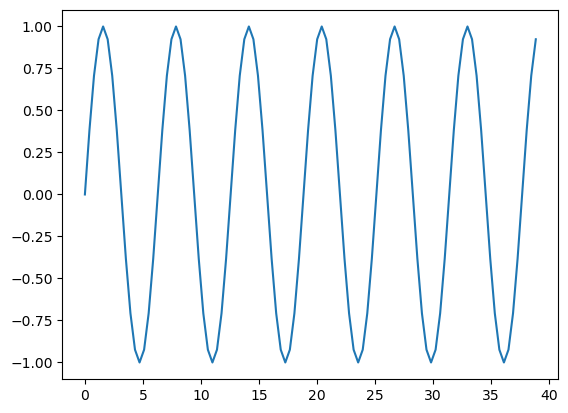

```python
plt.plot(xs, ys);
```

Instead of linearly (equally) spaced points, we can produce points spaced logarithmically using `np.logspace`:

```python
xs = np.logspace(start=0., stop=5., num=15, base=10.)
xs
```

```
array([1.00000000e+00, 2.27584593e+00, 5.17947468e+00, 1.17876863e+01,
       2.68269580e+01, 6.10540230e+01, 1.38949549e+02, 3.16227766e+02,
       7.19685673e+02, 1.63789371e+03, 3.72759372e+03, 8.48342898e+03,
       1.93069773e+04, 4.39397056e+04, 1.00000000e+05])
```

```python
ys = [x**2 for x in xs]
```

Here we start with the zeroth power of ten and end with the fifth power of 10.

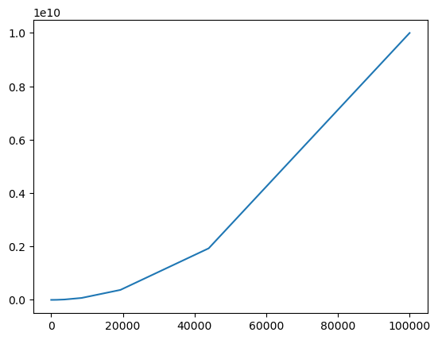

```python
plt.plot(xs, ys);
```

### Reasons to prefer NumPy arrays over standard Python data structures, such as lists

Suppose that we want to compute the sine of a number of regularly spaced angles (perhaps with a view of plotting the resulting graph):

```python
import math
```

```python
xs = [n * math.pi / 8. for n in range(10000)]
ys = [math.sin(x) for x in xs]
```

We can time the creation of each of the arrays, `xs` and `ys`, using the `timeit` cell magic:

```python
%timeit -o xs = [n * math.pi / 8. for n in range(10000)]
```

```
1.83 ms ± 616 µs per loop (mean ± std. dev. of 7 runs, 1,000 loops each)
```

```
<TimeitResult : 1.83 ms ± 616 µs per loop (mean ± std. dev. of 7 runs, 1,000 loops each)>
```

```python
%timeit -o ys = [math.sin(x) for x in xs]
```

```
2.25 ms ± 210 µs per loop (mean ± std. dev. of 7 runs, 100 loops each)
```

```
<TimeitResult : 2.25 ms ± 210 µs per loop (mean ± std. dev. of 7 runs, 100 loops each)>
```

We can replace the above Python lists with NumPy arrays and initialise them using **vectorised** operations (vectorised operations work on many values in one go), `np.linspace` and `np.sin`:

```python
xs = np.linspace(0., 9999. * math.pi / 8., 10000)
ys = np.sin(xs)
```

Let us time these operations.

```python
%timeit -o xs = np.linspace(0., 9999. * math.pi / 8., 10000)
```

```
41.1 µs ± 2.11 µs per loop (mean ± std. dev. of 7 runs, 10,000 loops each)
```

```
<TimeitResult : 41.1 µs ± 2.11 µs per loop (mean ± std. dev. of 7 runs, 10,000 loops each)>
```

```python
%timeit -o ys = np.sin(xs)
```

```
112 µs ± 6.67 µs per loop (mean ± std. dev. of 7 runs, 10,000 loops each)
```

```
<TimeitResult : 112 µs ± 6.67 µs per loop (mean ± std. dev. of 7 runs, 10,000 loops each)>
```

Vectorised operations on NumPy arrays take hundreds of *microseconds*, as opposed to *milliseconds* for Python lists, thus we have an order of magnitude improvement in speed.

Performance is one reason to prefer NumPy arrays over standard Python data structures, such as lists.

### Defining two-dimensional NumPy arrays (implementing matrices)

The real power of NumPy is in supporting two-dimensional, arrays, which can implement matrices:

```python
my_matrix = np.array([[4.28, 3.23, 5.87], [1.23, 5.32, 3.33]])
my_matrix
```

```
array([[4.28, 3.23, 5.87],
       [1.23, 5.32, 3.33]])
```

```python
np.ndim(my_matrix)
```

```
2
```

```python
np.size(my_matrix)
```

```
6
```

This particular two-dimensional NumPy array (matrix) is 2 by 3:

```python
np.shape(my_matrix)
```

```
(2, 3)
```

### Other ways of creating NumPy arrays

Instead of creating NumPy arrays from (either nested or flat) Python lists, we could use NumPy utility functions.

```python
np.zeros((3,))
```

```
array([0., 0., 0.])
```

will create a one-dimensional array of zeros of size three, whereas

```python
np.zeros((3, 5))
```

```
array([[0., 0., 0., 0., 0.],
       [0., 0., 0., 0., 0.],
       [0., 0., 0., 0., 0.]])
```

will create a two-dimensional array of zeros with three rows and five columns. In each case, the argument (`(3,)`, `(3, 5)`) is a tuple specifying the shape of the NumPy array, giving the size of each of its dimensions.

`np.zeros` takes an optional `dtype` (data type) argument. Thus instead of 64-bit floating point numbers, we could use 32-bit floating point numbers:

```python
np.zeros((3, 5), dtype='float32')
```

```
array([[0., 0., 0., 0., 0.],
       [0., 0., 0., 0., 0.],
       [0., 0., 0., 0., 0.]], dtype=float32)
```

Many GPUs are optimised for 32-bit, rather than 64-bit, precision.

Instead of an array of zeros, we could obtain an array of ones:

```python
np.ones((3,))
```

```
array([1., 1., 1.])
```

```python
np.ones((3, 5))
```

```
array([[1., 1., 1., 1., 1.],
       [1., 1., 1., 1., 1.],
       [1., 1., 1., 1., 1.]])
```

We could obtain an array with all values equal to a given number by multiplying the result of `np.ones` by that number:

```python
np.ones((3, 5)) * 7.5
```

```
array([[7.5, 7.5, 7.5, 7.5, 7.5],
       [7.5, 7.5, 7.5, 7.5, 7.5],
       [7.5, 7.5, 7.5, 7.5, 7.5]])
```

However, it is more efficient (this only really matters for large arrays) to use `np.full`:

```python
np.full((3, 5), 7.5)
```

```
array([[7.5, 7.5, 7.5, 7.5, 7.5],
       [7.5, 7.5, 7.5, 7.5, 7.5],
       [7.5, 7.5, 7.5, 7.5, 7.5]])
```

Unless you absolutely must initialise every value of an array to some number, it is most efficient to simply allocate the memory for the array (in which case you end up with whatever values that memory currently contains). This is done using `np.empty`:

```python
np.empty((3, 10))
```

```
array([[8.56849635e-312, 1.02765654e-321, 0.00000000e+000,
        0.00000000e+000, 9.18824177e-312, 5.02034658e+175,
        3.73835794e-061, 1.10497312e+165, 8.85426453e+165,
        3.43897401e+175],
       [8.68666981e-043, 5.83258408e-144, 3.59751658e+252,
        3.96046095e+246, 1.04918621e-153, 7.69165785e+218,
        5.04621343e+180, 1.04917822e-153, 9.08366793e+223,
        3.73835794e-061],
       [1.10497312e+165, 8.85426453e+165, 3.43897401e+175,
        1.04915136e-153, 1.94918966e-153, 9.72158982e-072,
        2.26267370e-076, 9.06496566e-043, 2.59027896e-144,
        7.79952704e-143]])
```

You are then responsible for setting the elements of the array appropriately, perhaps using a numerical algorithm.

Because no initialisation takes place, `np.empty` is typically more efficient than `np.zeros`:

```python
%timeit -o np.zeros((3, 10))
```

```
309 ns ± 12.4 ns per loop (mean ± std. dev. of 7 runs, 1,000,000 loops each)
```

```
<TimeitResult : 309 ns ± 12.4 ns per loop (mean ± std. dev. of 7 runs, 1,000,000 loops each)>
```

```python
%timeit -o np.empty((3, 10))
```

```
291 ns ± 24.4 ns per loop (mean ± std. dev. of 7 runs, 1,000,000 loops each)
```

```
<TimeitResult : 291 ns ± 24.4 ns per loop (mean ± std. dev. of 7 runs, 1,000,000 loops each)>
```

```python
%timeit -o np.zeros((10000000,))
```

```
18.9 µs ± 1.4 µs per loop (mean ± std. dev. of 7 runs, 100,000 loops each)
```

```
<TimeitResult : 18.9 µs ± 1.4 µs per loop (mean ± std. dev. of 7 runs, 100,000 loops each)>
```

```python
%timeit -o np.empty((10000000,))
```

```
18.8 µs ± 1.76 µs per loop (mean ± std. dev. of 7 runs, 10,000 loops each)
```

```
<TimeitResult : 18.8 µs ± 1.76 µs per loop (mean ± std. dev. of 7 runs, 10,000 loops each)>
```

However, the operating system may initialise large newly allocated chunks of memory to zero for security reasons, which may make the difference in performance immaterial.

Matrices can also be created out of blocks using `np.tile`:

```python
np.tile([[4.28, 3.23, 5.87], [1.23, 5.32, 3.33]], (2, 3))
```

```
array([[4.28, 3.23, 5.87, 4.28, 3.23, 5.87, 4.28, 3.23, 5.87],
       [1.23, 5.32, 3.33, 1.23, 5.32, 3.33, 1.23, 5.32, 3.33],
       [4.28, 3.23, 5.87, 4.28, 3.23, 5.87, 4.28, 3.23, 5.87],
       [1.23, 5.32, 3.33, 1.23, 5.32, 3.33, 1.23, 5.32, 3.33]])
```

### Generating random matrices

NumPy's `np.random.random` returns random floats in the half-open interval $[0, 1)$. Results are sampled from the continuous uniform distribution over this interval.

```python
np.random.random((2, 3))
```

```
array([[0.34081837, 0.05191541, 0.50609225],
       [0.8878024 , 0.328979  , 0.90749874]])
```

To sample from $\text{Uniform}[a, b)$, $b > a$, multiply the output by $(b - a)$ and add $a$:

```python
np.random.random((2, 3)) * 10. + 100.
```

```
array([[104.41376148, 104.04161426, 109.15663435],
       [108.6686644 , 103.38246868, 104.99669658]])
```

### Reshaping matrices

Once a matrix has been created,

```python
my_matrix = np.array([[4.28, 3.23, 5.87], [1.23, 5.32, 3.33]])
my_matrix
```

```
array([[4.28, 3.23, 5.87],
       [1.23, 5.32, 3.33]])
```

Its shape,

```python
my_matrix.shape
```

```
(2, 3)
```

can be changed:

```python
my_matrix.shape = (3, 2)
my_matrix
```

```
array([[4.28, 3.23],
       [5.87, 1.23],
       [5.32, 3.33]])
```

```python
my_matrix.shape = (6,)
my_matrix
```

```
array([4.28, 3.23, 5.87, 1.23, 5.32, 3.33])
```

```python
my_matrix.shape = ((6, 1))
my_matrix
```

```
array([[4.28],
       [3.23],
       [5.87],
       [1.23],
       [5.32],
       [3.33]])
```

```python
my_matrix.shape = ((1, 6))
my_matrix
```

```
array([[4.28, 3.23, 5.87, 1.23, 5.32, 3.33]])
```

We could also use `np.reshape`, which works on Python lists as well as NumPy arrays:

```python
my_reshaped_matrix = np.reshape(my_matrix, (2, 3))
my_reshaped_matrix
```

```
array([[4.28, 3.23, 5.87],
       [1.23, 5.32, 3.33]])
```

```python
my_matrix = my_reshaped_matrix
```

```python
np.reshape([[4.28, 3.23, 5.87], [1.23, 5.32, 3.33]], (6, 1))
```

```
array([[4.28],
       [3.23],
       [5.87],
       [1.23],
       [5.32],
       [3.33]])
```

### Multiplying matrices by scalars

Such matrices can be multiplied by scalars:

```python
3. * my_matrix
```

```
array([[12.84,  9.69, 17.61],
       [ 3.69, 15.96,  9.99]])
```

### Adding matrices

Added together:

```python
my_matrix + np.array([[3.00, 0., 0.], [5., 7., 0.]])
```

```
array([[ 7.28,  3.23,  5.87],
       [ 6.23, 12.32,  3.33]])
```

### Multiplying matrices

And multiplied by other compatible matrices:

```python
A = np.dot(my_matrix, np.array([[3., 1.], [1., -3.], [-3., -3.]]))
A
```

```
array([[ -1.54, -23.02],
       [ -0.98, -24.72]])
```

We can also realise this as

```python
my_matrix @ np.array([[3., 1.], [1., -3.], [-3., -3.]])
```

```
array([[ -1.54, -23.02],
       [ -0.98, -24.72]])
```

### Mixing arrays and scalars in arithmetic operations

We can mix arrays and scalars in arithmetic expressions:

```python
10. * my_matrix - 2. * my_matrix * my_matrix + 1.
```

```
array([[ 7.1632, 12.4342, -9.2138],
       [10.2742, -2.4048, 12.1222]])
```

The scalar is applied elementwise to each element of the array — we say that the scalar is **broadcast** across every element of the array:

```python
my_matrix
```

```
array([[4.28, 3.23, 5.87],
       [1.23, 5.32, 3.33]])
```

```python
10. * my_matrix
```

```
array([[42.8, 32.3, 58.7],
       [12.3, 53.2, 33.3]])
```

```python
10. * my_matrix + 1.
```

```
array([[43.8, 33.3, 59.7],
       [13.3, 54.2, 34.3]])
```

Arrays can also be broadcast:

```python
a = np.array([[1., 3., 2.], [5., 8., 7.], [3., 2., 1]])
a
```

```
array([[1., 3., 2.],
       [5., 8., 7.],
       [3., 2., 1.]])
```

```python
b = np.array([[101.], [102.], [103.]])
b
```

```
array([[101.],
       [102.],
       [103.]])
```

```python
a + b
```

```
array([[102., 104., 103.],
       [107., 110., 109.],
       [106., 105., 104.]])
```

### Transposing matrices

Matrices can be transposed (flipped on their side):

```python
A.T
```

```
array([[ -1.54,  -0.98],
       [-23.02, -24.72]])
```

```python
my_matrix.T
```

```
array([[4.28, 1.23],
       [3.23, 5.32],
       [5.87, 3.33]])
```

### Matrix inverses

NumPy can also be used to invert a matrix, i.e. to find such a matrix that, when multiplied by the given matrix, will give the identity matrix:

```python
Ainv = np.linalg.inv(A)
Ainv
```

```
array([[-1.59389266,  1.4842803 ],
       [ 0.0631883 , -0.0992959 ]])
```

In mathematics it is customary to denote the inverse of $A$ by $A^{-1}$. Let us check that the product $A A^{-1}$ is indeed equal to the identity matrix:

```python
np.dot(A, Ainv)
```

```
array([[1., 0.],
       [0., 1.]])
```

The product $A^{-1} A$ should also give the identity:

```python
np.dot(Ainv, A)
```

```
array([[ 1.00000000e+00, -7.10542736e-15],
       [-1.38777878e-17,  1.00000000e+00]])
```

(Close enough.)

### The identity matrix

To obtain the identity matrix of a given size, we can use `np.eye`:

```python
np.eye(1)
```

```
array([[1.]])
```

```python
np.eye(2)
```

```
array([[1., 0.],
       [0., 1.]])
```

```python
np.eye(3)
```

```
array([[1., 0., 0.],
       [0., 1., 0.],
       [0., 0., 1.]])
```

### Stacking NumPy arrays horizontally

Let's say that we have a 5 by 4 NumPy array,

```python
array1 = np.array([
    [10., 20., 30., 40.],
    [50., 60., 70., 80.],
    [90., 100., 110., 120.],
    [130., 140., 150., 160.],
    [170., 180., 190., 200.]])
array1
```

```
array([[ 10.,  20.,  30.,  40.],
       [ 50.,  60.,  70.,  80.],
       [ 90., 100., 110., 120.],
       [130., 140., 150., 160.],
       [170., 180., 190., 200.]])
```

and another 5 by 3 NumPy array,

```python
array2 = np.array([
    [1., 2., 3.],
    [4., 5., 6.],
    [7., 8., 9.],
    [10., 11., 12.],
    [13., 14., 15.]])
array2
```

```
array([[ 1.,  2.,  3.],
       [ 4.,  5.,  6.],
       [ 7.,  8.,  9.],
       [10., 11., 12.],
       [13., 14., 15.]])
```

We can stack these two arrays horizontally:

```python
np.hstack((array1, array2))
```

```
array([[ 10.,  20.,  30.,  40.,   1.,   2.,   3.],
       [ 50.,  60.,  70.,  80.,   4.,   5.,   6.],
       [ 90., 100., 110., 120.,   7.,   8.,   9.],
       [130., 140., 150., 160.,  10.,  11.,  12.],
       [170., 180., 190., 200.,  13.,  14.,  15.]])
```

### Stacking NumPy arrays vertically

It is also possible to stack arrays vertically:

```python
array1 = np.array([
    [1., 2.],
    [3., 4.],
    [5., 6.]])
```

```python
array2 = np.array([
    [10., 20.]])
```

```python
array3 = np.array([
    [100., 200.],
    [300., 400.],
    [500., 600.],
    [700., 800.]])
```

```python
np.vstack((array1, array2, array3))
```

```
array([[  1.,   2.],
       [  3.,   4.],
       [  5.,   6.],
       [ 10.,  20.],
       [100., 200.],
       [300., 400.],
       [500., 600.],
       [700., 800.]])
```

### Indexing NumPy arrays

Let us consider, for example, the NumPy array

```python
a = np.array([
    [10., 20., 30., 40.],
    [50., 60., 70., 80.],
    [90., 100., 110., 120.],
    [130., 140., 150., 160.],
    [170., 180., 190., 200.]])
```

To index a particular element of this array, we can use

```python
a[0, 0]
```

```
10.0
```

```python
a[2, 3]
```

```
120.0
```

NumPy arrays are mutable, so we can overwrite the values:

```python
a[2, 3] = a[2, 3] * 10.
```

```python
a
```

```
array([[  10.,   20.,   30.,   40.],
       [  50.,   60.,   70.,   80.],
       [  90.,  100.,  110., 1200.],
       [ 130.,  140.,  150.,  160.],
       [ 170.,  180.,  190.,  200.]])
```

It is possible to index an entire row

```python
a[3, :]
```

```
array([130., 140., 150., 160.])
```

or column

```python
a[:, 3]
```

```
array([  40.,   80., 1200.,  160.,  200.])
```

We can thus set each element in a particular row to a specific value:

```python
a[3, :] = 100.
```

```python
a
```

```
array([[  10.,   20.,   30.,   40.],
       [  50.,   60.,   70.,   80.],
       [  90.,  100.,  110., 1200.],
       [ 100.,  100.,  100.,  100.],
       [ 170.,  180.,  190.,  200.]])
```

More complex indexing enables us to access subblocks of a NumPy array

```python
a[0:4, 1:3]
```

```
array([[ 20.,  30.],
       [ 60.,  70.],
       [100., 110.],
       [100., 100.]])
```

In addition to the start index (inclusive) and end index (exclusive), we may also provide the step size:

```python
a[0:4:2, 1:3]
```

```
array([[ 20.,  30.],
       [100., 110.]])
```

It is important that the result of **slicing** an array in this manner is a view of the original array:

```python
a
```

```
array([[  10.,   20.,   30.,   40.],
       [  50.,   60.,   70.,   80.],
       [  90.,  100.,  110., 1200.],
       [ 100.,  100.,  100.,  100.],
       [ 170.,  180.,  190.,  200.]])
```

```python
b = a[0:4:2, 1:3]
```

```python
b
```

```
array([[ 20.,  30.],
       [100., 110.]])
```

```python
b[:] = 1000.
```

```python
b
```

```
array([[1000., 1000.],
       [1000., 1000.]])
```

```python
a
```

```
array([[  10., 1000., 1000.,   40.],
       [  50.,   60.,   70.,   80.],
       [  90., 1000., 1000., 1200.],
       [ 100.,  100.,  100.,  100.],
       [ 170.,  180.,  190.,  200.]])
```

Notice that the original array has changed. To avoid thid, take a copy of the slice:

```python
b = a[0:4:2, 1:3].copy()
```

### Boolean indexing

Just as `pandas` `DataFrame`s support boolean indexing, so do NumPy arrays:

```python
a > 5
```

```
array([[ True,  True,  True,  True],
       [ True,  True,  True,  True],
       [ True,  True,  True,  True],
       [ True,  True,  True,  True],
       [ True,  True,  True,  True]])
```

```python
a[a > 5]
```

```
array([  10., 1000., 1000.,   40.,   50.,   60.,   70.,   80.,   90.,
       1000., 1000., 1200.,  100.,  100.,  100.,  100.,  170.,  180.,
        190.,  200.])
```

```python
a[a > 5] = 100.
```

```python
a
```

```
array([[100., 100., 100., 100.],
       [100., 100., 100., 100.],
       [100., 100., 100., 100.],
       [100., 100., 100., 100.],
       [100., 100., 100., 100.]])
```

### Comparing arrays

One should be careful when comparing NumPy arrays, being mindful that one is dealing with floating point data.

```python
a = np.random.random(1000000)
```

```python
np.all(3 * (5 * a) * (7 * a) == 105 * a * a)
```

```
False
```

However, the maximum absolute difference between the corresponding elements is small:

```python
np.max(np.abs(3 * (5 * a) * (7 * a) - 105 * a * a))
```

```
2.842170943040401e-14
```

Thus for most practical purposes the arrays are equal.

```python
np.max(np.abs(3 * (5 * a) * (7 * a) - 105 * a * a)) < 1e-12
```

```
True
```

### Some useful functions

Consider the matrix

```python
a = np.array([
    [3.29, 3.12, 9.49, 4.28, 9.93],
    [3.21, 9.93, 0.90, 8.90, 2.33],
    [5.32, 9.90, 1.23, 9.89, 2.39]
])
```

To find the cumulative sums:

```python
np.cumsum(a)
```

```
array([ 3.29,  6.41, 15.9 , 20.18, 30.11, 33.32, 43.25, 44.15, 53.05,
       55.38, 60.7 , 70.6 , 71.83, 81.72, 84.11])
```

The cumulative products:

```python
np.cumprod(a)
```

```
array([3.29000000e+00, 1.02648000e+01, 9.74129520e+01, 4.16927435e+02,
       4.14008943e+03, 1.32896871e+04, 1.31966592e+05, 1.18769933e+05,
       1.05705241e+06, 2.46293210e+06, 1.31027988e+07, 1.29717708e+08,
       1.59552781e+08, 1.57797700e+09, 3.77136504e+09])
```

The minimum:

```python
np.min(a)
```

```
0.9
```

The maximum:

```python
np.max(a)
```

```
9.93
```

The index at which the minimum is attained:

```python
np.argmin(a)
```

```
7
```

The index at which the maximum is attained:

```python
np.argmax(a)
```

```
4
```

The mean:

```python
np.mean(a)
```

```
5.607333333333333
```

The variance:

```python
np.var(a)
```

```
12.10776622222222
```

The standard deviation:

```python
np.std(a)
```

```
3.4796215630758214
```

### Applying a function to each row or column

Consider the matrix

```python
a = np.array([
    [3.29, 3.12, 9.49, 4.28, 9.93],
    [3.21, 9.93, 0.90, 8.90, 2.33],
    [5.32, 9.90, 1.23, 9.89, 2.39]
])
```

Often we need to apply a function to each row or to each column of a matrix. In these cases `np.apply_along_axis` comes in useful.

For example, to find the mean of each row we could use

```python
np.apply_along_axis(np.mean, 1, a)
```

```
array([6.022, 5.054, 5.746])
```

To find the mean of each column

```python
np.apply_along_axis(np.mean, 0, a)
```

```
array([3.94      , 7.65      , 3.87333333, 7.69      , 4.88333333])
```

### Flags; making NumPy arrays immutable

Let's again consider the NumPy array

```python
a = np.array([
    [3.29, 3.12, 9.49, 4.28, 9.93],
    [3.21, 9.93, 0.90, 8.90, 2.33],
    [5.32, 9.90, 1.23, 9.89, 2.39]
])
```

Let's have a look at its `flags`:

```python
a.flags
```

```
  C_CONTIGUOUS : True
  F_CONTIGUOUS : False
  OWNDATA : True
  WRITEABLE : True
  ALIGNED : True
  WRITEBACKIFCOPY : False
```

In particular, we see that the array is stored row-by-row (`C_CONTIGUOUS`) as opposed to column-by-column. Its transpose view will naturally be `F_CONTIGUOUS`:

```python
a.T.flags
```

```
  C_CONTIGUOUS : False
  F_CONTIGUOUS : True
  OWNDATA : False
  WRITEABLE : True
  ALIGNED : True
  WRITEBACKIFCOPY : False
```

Another useful flag is `WRITEABLE`. We may set it to `False` in order to make a NumPy array immutable. This is useful if we want to make sure that we don't accidentally change the values in the array, e.g. when we pass it round to functions:

```python
a[0, 0] = 9.23
```

```python
a.flags.writeable = False
```

Something like `a[0, 0] = 1.23` will now throw `ValueError: assignment destination is read-only`.

Of course, if someone *really* wants to modify the array, they can set

```python
a.flags.writeable = True
```

```python
a[0, 0] = 1.23
```

```python
a
```

```
array([[1.23, 3.12, 9.49, 4.28, 9.93],
       [3.21, 9.93, 0.9 , 8.9 , 2.33],
       [5.32, 9.9 , 1.23, 9.89, 2.39]])
```

### Finding out more about the configuration of the NumPy library

We can find out the version of the NumPy library using

```python
np.version.version
```

```
'1.24.3'
```

To check which BLAS (Basic Linear Algebra Subprograms, a lower level library) is being used by NumPy, use

```python
np.show_config()
```

```
blas_armpl_info:
  NOT AVAILABLE
blas_mkl_info:
    libraries = ['mkl_rt']
    library_dirs = ['C:/Programs/Win64/Anaconda/V2023.09-0_3.11\\Library\\lib']
    define_macros = [('SCIPY_MKL_H', None), ('HAVE_CBLAS', None)]
    include_dirs = ['C:/Programs/Win64/Anaconda/V2023.09-0_3.11\\Library\\include']
blas_opt_info:
    libraries = ['mkl_rt']
    library_dirs = ['C:/Programs/Win64/Anaconda/V2023.09-0_3.11\\Library\\lib']
    define_macros = [('SCIPY_MKL_H', None), ('HAVE_CBLAS', None)]
    include_dirs = ['C:/Programs/Win64/Anaconda/V2023.09-0_3.11\\Library\\include']
lapack_armpl_info:
  NOT AVAILABLE
lapack_mkl_info:
    libraries = ['mkl_rt']
    library_dirs = ['C:/Programs/Win64/Anaconda/V2023.09-0_3.11\\Library\\lib']
    define_macros = [('SCIPY_MKL_H', None), ('HAVE_CBLAS', None)]
    include_dirs = ['C:/Programs/Win64/Anaconda/V2023.09-0_3.11\\Library\\include']
lapack_opt_info:
    libraries = ['mkl_rt']
    library_dirs = ['C:/Programs/Win64/Anaconda/V2023.09-0_3.11\\Library\\lib']
    define_macros = [('SCIPY_MKL_H', None), ('HAVE_CBLAS', None)]
    include_dirs = ['C:/Programs/Win64/Anaconda/V2023.09-0_3.11\\Library\\include']
Supported SIMD extensions in this NumPy install:
    baseline = SSE,SSE2,SSE3
    found = SSSE3,SSE41,POPCNT,SSE42,AVX,F16C,FMA3,AVX2
    not found = AVX512F,AVX512CD,AVX512_SKX,AVX512_CLX,AVX512_CNL,AVX512_ICL
```

#### Exercise

Consider the matrix

```python
a = np.array([[3.89, 3.90, 1.39], [2.90, 4.32, 8.32], [5.32, 9.90, 8.98]])
a
```

```
array([[3.89, 3.9 , 1.39],
       [2.9 , 4.32, 8.32],
       [5.32, 9.9 , 8.98]])
```

The elements 3.89, 4.32, and 8.98 constitute the **diagonal** of this matrix. "Bump" the diagonal (increase each entry in the diagonal) by 10.0.

#### Solution

```python
for i in range(np.shape(a)[0]):
    a[i, i] += 10.
```

```python
a
```

```
array([[13.89,  3.9 ,  1.39],
       [ 2.9 , 14.32,  8.32],
       [ 5.32,  9.9 , 18.98]])
```

#### Exercise

Consider the matrix

```python
a = np.array([[3.89, 3.90, 1.39], [2.90, 4.32, 8.32], [5.32, 9.90, 8.98]])
a
```

```
array([[3.89, 3.9 , 1.39],
       [2.9 , 4.32, 8.32],
       [5.32, 9.9 , 8.98]])
```

Save the diagonal of this matrix in a flat (one-dimensional) numpy array.

#### Solution

```python
d = np.empty((np.shape(a)[0],))
for i in range(np.shape(a)[0]):
    d[i] = a[i, i]
```

```python
d
```

```
array([3.89, 4.32, 8.98])
```

#### Exercise

Stack the NumPy arrays to obtain a single matrix, where the top left block is the 3 by 3 identity matrix, the top right block the 3 by 4 zero matrix, the bottom left block the 4 by 3 matrix of ones, and the bottom right block the 4 by 4 matrix of 3s.

#### Solution

```python
tl = np.eye(3)
tr = np.zeros((3, 4))
bl = np.ones((4, 3))
br = np.ones((4, 4)) * 3
t = np.hstack((tl, tr))
b = np.hstack((bl, br))
a = np.vstack((t, b))
a
```

```
array([[1., 0., 0., 0., 0., 0., 0.],
       [0., 1., 0., 0., 0., 0., 0.],
       [0., 0., 1., 0., 0., 0., 0.],
       [1., 1., 1., 3., 3., 3., 3.],
       [1., 1., 1., 3., 3., 3., 3.],
       [1., 1., 1., 3., 3., 3., 3.],
       [1., 1., 1., 3., 3., 3., 3.]])
```

#### Exercise

What is the result of multiplying the matrix from the previous exercise by the vector (column matrix)

```python
v = np.array([[1.], [2.], [3.], [4.], [5.], [6.], [7.]])
```

#### Solution

```python
np.dot(a, v)
```

```
array([[ 1.],
       [ 2.],
       [ 3.],
       [72.],
       [72.],
       [72.],
       [72.]])
```

#### Exercise

Consider the matrix

```python
a = np.array([
    [3.29, 3.12, 9.49, 4.28, 9.93],
    [3.21, 9.93, 0.90, 8.90, 2.33],
    [5.32, 9.90, 1.23, 9.89, 2.39]
])
```

Find the minimum in each even-indexed (0th, 2nd, etc.) column and the maximum in each odd-indexed (1st, 3rd, etc.) column.

#### Solution

```python
np.apply_along_axis(np.min, 0, a[:, 0::2])
```

```
array([3.21, 0.9 , 2.33])
```

```python
np.apply_along_axis(np.max, 0, a[:, 1::2])
```

```
array([9.93, 9.89])
```

#### Exercise

Use `np.zeros` and indexing to create the NumPy array

array([[0., 5., 0., 0., 0., 0., 0.], [8., 0., 5., 0., 0., 0., 0.], [0., 8., 0., 5., 0., 0., 0.], [0., 0., 8., 0., 5., 0., 0.], [0., 0., 0., 8., 0., 5., 0.], [0., 0., 0., 0., 8., 0., 5.], [0., 0., 0., 0., 0., 8., 0.]])

#### Solution

```python
a = np.zeros(49)
a[1::8] = 5.
a[7::8] = 8.
a.shape = (7, 7)
a
```

```
array([[0., 5., 0., 0., 0., 0., 0.],
       [8., 0., 5., 0., 0., 0., 0.],
       [0., 8., 0., 5., 0., 0., 0.],
       [0., 0., 8., 0., 5., 0., 0.],
       [0., 0., 0., 8., 0., 5., 0.],
       [0., 0., 0., 0., 8., 0., 5.],
       [0., 0., 0., 0., 0., 8., 0.]])
```